# ALY6040 M3 Signature Assignment - EDA

Instructor: Dr. Marcus Ellis

Student: Shahabaddin Feghahati

Completion Date: 03/12/2023

#### Introduction

In this study, we aim to perform data preprocessing and Exploratory Data Analysis (EDA) on two datasets - application_record and credit_record. To achieve this, we begin by loading various libraries such as dplyr, tidyr, magrittr, kableExtra, ggplot2, GGally, and psych.

The first step is to display the structure of both datasets and conduct data completeness, accuracy, and validity checks. To start, we look for duplicate values in both datasets and then check for missing values using the sum() function. Next, we perform accuracy checks by summarizing the credit_record. For application_record, we generate a table using summarytools and format it using kable_classic().

We proceed by removing unrealistic values in application_record by deleting rows with values outside the specified range. We then convert DAYS_BIRTH to AGE and DAYS_EMPLOYED to YEARS_EMPLOYED by dividing by -365.25. If the value is positive, we replace it with zero to indicate that the person is currently unemployed.

To identify outliers in the dataset, we conduct EDA by displaying a boxplot matrix of outlier-prone numeric variables in the application_record dataset. We convert the dataset to a matrix and plot boxplots for each pair or single variable. To enhance the data transformation process, we apply a slight modification by replacing 0 values with 0.1 in the YEARS_EMPLOYED variable. Then, we apply a logarithmic transformation to both YEARS_EMPLOYED and AMT_INCOME_TOTAL variables to improve their distribution.

Moving on, we merge the two datasets, creating a cross-tabulation table, and generating a bar plot of credit status by gender. Additionally, we create a random sample of 100 points and generate a scatterplot matrix of numerical variables in the credit application dataset.

Finally, we conduct a Chi-square test to reveal the relationship between credit status and categorical variables in the dataset. Overall, these preprocessing and EDA steps enable us to obtain a clean and well-structured dataset, which is necessary for accurate data analysis and modeling.

#### Analysis

```r
# Load the necessary packages/libraries and datasets

#Loading libraries
library(dplyr)
library(tidyr)
library(magrittr)
library(kableExtra)
library(ggplot2)
library(GGally)
library(psych)

application_record <- read.csv("application_record.csv")
credit_record <- read.csv("credit_record.csv")
```

##### Display the structure of application_record

```r
str(application_record)
```

```
## 'data.frame':    438557 obs. of  18 variables:
##  $ ID                 : int  5008804 5008805 5008806 5008808 5008809 5008810 5008811 5008812 5008813 5008814 ...
##  $ CODE_GENDER        : chr  "M" "M" "M" "F" ...
##  $ FLAG_OWN_CAR       : chr  "Y" "Y" "Y" "N" ...
##  $ FLAG_OWN_REALTY    : chr  "Y" "Y" "Y" "Y" ...
##  $ CNT_CHILDREN       : int  0 0 0 0 0 0 0 0 0 0 ...
##  $ AMT_INCOME_TOTAL   : num  427500 427500 112500 270000 270000 ...
##  $ NAME_INCOME_TYPE   : chr  "Working" "Working" "Working" "Commercial associate" ...
##  $ NAME_EDUCATION_TYPE: chr  "Higher education" "Higher education" "Secondary / secondary special" "Secondary / secondary special" ...
##  $ NAME_FAMILY_STATUS : chr  "Civil marriage" "Civil marriage" "Married" "Single / not married" ...
##  $ NAME_HOUSING_TYPE  : chr  "Rented apartment" "Rented apartment" "House / apartment" "House / apartment" ...
##  $ DAYS_BIRTH         : int  -12005 -12005 -21474 -19110 -19110 -19110 -19110 -22464 -22464 -22464 ...
##  $ DAYS_EMPLOYED      : int  -4542 -4542 -1134 -3051 -3051 -3051 -3051 365243 365243 365243 ...
##  $ FLAG_MOBIL         : int  1 1 1 1 1 1 1 1 1 1 ...
##  $ FLAG_WORK_PHONE    : int  1 1 0 0 0 0 0 0 0 0 ...
##  $ FLAG_PHONE         : int  0 0 0 1 1 1 1 0 0 0 ...
##  $ FLAG_EMAIL         : int  0 0 0 1 1 1 1 0 0 0 ...
##  $ OCCUPATION_TYPE    : chr  "" "" "Security staff" "Sales staff" ...
##  $ CNT_FAM_MEMBERS    : int  2 2 2 1 1 1 1 1 1 1 ...
```

The data is a data frame with 438,557 observations and 18 variables. The variables include information on the individual’s demographic characteristics (such as gender, age, education, family status, and income), employment status (such as occupation and employment length), and various flags indicating whether the individual owns a car or property, has a mobile or work phone, or has provided an email address. The data is related to credit risk assessment and loan applications.

##### Display the structure of credit_record

```r
str(credit_record)
```

```
## 'data.frame':    1048575 obs. of  3 variables:
##  $ ID            : int  5001711 5001711 5001711 5001711 5001712 5001712 5001712 5001712 5001712 5001712 ...
##  $ MONTHS_BALANCE: int  0 -1 -2 -3 0 -1 -2 -3 -4 -5 ...
##  $ STATUS        : chr  "X" "0" "0" "0" ...
```

The data is a data frame with 1,048,575 observations and 3 variables. The variables include an ID representing a unique individual identifier, a MONTHS_BALANCE variable representing the number of months before the current month, and a STATUS variable representing the credit status of the individual in that month. The STATUS variable seems to indicate the payment status of a loan or credit card account, with “X” indicating no loan for the given month and numeric values indicating the number of days the payment is past due.

##### Check for duplicate values

```r
# Find duplicates
dupes <- application_record[duplicated(application_record), ]
dupes_ <- application_record[duplicated(credit_record), ]

# Print duplicates
print(dupes)
print(dupes_)
```

Code result: Empty data frame = No duplicate rows in application_record and credit_record data sets. Duplicates can cause inaccuracies/biases in analysis. Absence of duplicates doesn’t mean data is error-free. Other issues may exist like missing/incorrect values, outliers, or data entry errors. Checking duplicates is one step in data cleaning, combine with other quality checks/validation methods for reliable/accurate data for intended analysis.

##### Check for missing values (completeness check)

```r
# Check for missing values in application_record dataset
sum(is.na(application_record))

# Check for missing values in credit_record dataset
sum(is.na(credit_record))
```

[output not shown]

The output indicates that there are no missing values in both the application_record and credit_record datasets.

This means that each variable in both datasets has a value for every observation, and there are no observations with missing values.

This is a good sign as missing data can cause issues with data analysis and modeling, such as biased results, reduced statistical power, or inaccurate conclusions. Therefore, having complete datasets with no missing values can increase the validity and reliability of any analysis performed on these datasets.

##### Check for accuracy (invalid values and outliers)

```r
# Summarize the credit_record
credit_record %>% summarytools::descr() %>% round(2) %>% knitr::kable(align = "c") %>% kable_classic(c("striped", "hover"), font_size = 16)

# Save the output of summarytools::descr() as a data frame
credit_record_summary <- summarytools::descr(credit_record[, c("ID", "MONTHS_BALANCE")], transpose = TRUE)

# Write the output to a CSV file using write_csv with file argument
readr::write_csv(credit_record_summary, file = "cr_df_summary.csv")
```

[output not shown]

The dataset includes credit records of customers for up to 60 months before their current application. The average MONTHS_BALANCE is -19.14 (SD = 14.02), and the minimum and maximum MONTHS_BALANCE are -60 and 0, respectively. The median value is -17, and the IQR value of 22 indicates that 50% of the observations lie between -29 and -7 months of credit record. A negative CV value of -0.73 for MONTHS_BALANCE suggests a highly skewed left distribution, indicating that most customers in the dataset have relatively recent credit histories. Additionally, a negative skewness (-0.62) indicates a long tail of observations towards the lower end of the range. The kurtosis value (-0.48) suggests a relatively flat distribution with fewer outliers than expected for a normal distribution. However, it is important to note that further investigation is necessary to ensure the accuracy and meaningfulness of the negative CV value.

```r
library(summarytools)
library(knitr)
library(htmltools)
# Summarize the application_record

# Generate the table and format it using kable_classic()
table_html <- application_record %>%
  summarytools::descr() %>%
  round(2) %>%
  knitr::kable(align = "c") %>%
  kable_classic(c("striped", "hover"), font_size = 16)

# Wrap the table in a div element with horizontal scrolling
table_div <- tags$div(
  style = "overflow-x: auto; width: 100%;",
  HTML(table_html)
)

# Display the table
table_div
```

|  | AMT_INCOME_TOTAL | CNT_CHILDREN | CNT_FAM_MEMBERS | DAYS_BIRTH | DAYS_EMPLOYED | FLAG_EMAIL | FLAG_MOBIL | FLAG_PHONE | FLAG_WORK_PHONE | ID |
| --- | --- | --- | --- | --- | --- | --- | --- | --- | --- | --- |
| Mean | 187524.29 | 0.43 | 2.19 | -15997.90 | 60563.68 | 0.11 | 1 | 0.29 | 0.21 | 6022176.27 |
| Std.Dev | 110086.85 | 0.72 | 0.90 | 4185.03 | 138767.80 | 0.31 | 0 | 0.45 | 0.40 | 571637.02 |
| Min | 26100.00 | 0.00 | 1.00 | -25201.00 | -17531.00 | 0.00 | 1 | 0.00 | 0.00 | 5008804.00 |
| Q1 | 121500.00 | 0.00 | 2.00 | -19483.00 | -3103.00 | 0.00 | 1 | 0.00 | 0.00 | 5609375.00 |
| Median | 160780.50 | 0.00 | 2.00 | -15630.00 | -1467.00 | 0.00 | 1 | 0.00 | 0.00 | 6047745.00 |
| Q3 | 225000.00 | 1.00 | 3.00 | -12514.00 | -371.00 | 0.00 | 1 | 1.00 | 0.00 | 6456971.00 |
| Max | 6750000.00 | 19.00 | 20.00 | -7489.00 | 365243.00 | 1.00 | 1 | 1.00 | 1.00 | 7999952.00 |
| MAD | 71580.67 | 0.00 | 0.00 | 5116.45 | 1884.38 | 0.00 | 0 | 0.00 | 0.00 | 624829.91 |
| IQR | 103500.00 | 1.00 | 1.00 | 6969.00 | 2732.00 | 0.00 | 0 | 1.00 | 0.00 | 847596.00 |
| CV | 0.59 | 1.70 | 0.41 | -0.26 | 2.29 | 2.87 | 0 | 1.57 | 1.96 | 0.09 |
| Skewness | 8.83 | 1.81 | 0.92 | -0.16 | 1.74 | 2.52 | NaN | 0.94 | 1.45 | 0.21 |
| SE.Skewness | 0.00 | 0.00 | 0.00 | 0.00 | 0.00 | 0.00 | 0 | 0.00 | 0.00 | 0.00 |
| Kurtosis | 324.55 | 5.08 | 1.90 | -1.05 | 1.03 | 4.36 | NaN | -1.12 | 0.11 | -0.09 |
| N.Valid | 438557.00 | 438557.00 | 438557.00 | 438557.00 | 438557.00 | 438557.00 | 438557 | 438557.00 | 438557.00 | 438557.00 |
| Pct.Valid | 100.00 | 100.00 | 100.00 | 100.00 | 100.00 | 100.00 | 100 | 100.00 | 100.00 | 100.00 |

The data provided gives insights into the credit application record of the applicants. Here are some of the insights that can be extracted from the given data:

The mean income of the applicants is 187,524.29 and the standard deviation is 110,086.85. This indicates that there is a wide variation in the income levels of the applicants.

On average, applicants have less than one child and two family members. This suggests that most of the applicants are single or married couples without children.

The mean age of the applicants is around 44 years old. The minimum age is around 21 years old and the maximum age is around 69 years old.

The majority of the applicants did not provide an email address in their application, with only 11% providing one.

All of the applicants provided a mobile number in their application, indicating that having a mobile number is an essential requirement for applying for credit.

29% of the applicants provided a landline phone number, and 21% provided a work phone number.

The data suggests that there are some outliers in the number of children and family members, with some applicants having as many as 19 and 20 children or family members respectively.

The skewness values for income, number of children, number of family members, and days employed indicate that these variables are highly skewed.

The data also suggests that there are no missing values in the variables, and all variables have the same number of valid observations.

The dataset contains very low or very high income values that are not realistic, then it may indicate errors in the data entry or processing.

To identify very low or very high values that are not realistic, we need to use domain knowledge and common sense about the variables we are analyzing. Based on the summary output provided, we can define unrealistic values as follows:

For the CNT_CHILDREN variable in the application_record dataset, a maximum value of 19 seems unrealistic since it represents an extremely large family. Therefore, we will consider any value greater than 5 as unrealistic.

For the AMT_INCOME_TOTAL variable in the application_record dataset, both very low and very high values may be unrealistic. We will consider any value less than 10000 or greater than 1000000 as unrealistic.

For the CNT_FAM_MEMBERS variable in the application_record dataset, a maximum value of 20 seems unrealistic since it represents an extremely large family. Therefore, we will consider any value greater than 6 as unrealistic.

To handle unrealistic income values, consider different strategies based on context and specific values such as replacing with missing values, using default or typical values, or manually reviewing and correcting. Deleting unrealistic values is an option for data quality issues, but exercise caution and consider consequences. Assess reasons and potential impact before deciding to delete values, as correcting or imputing values may be possible for data entry errors or quality issues, while deleting rare outliers may affect statistical properties.

##### Delete unrealistic values in application_record dataset

```r
# Delete unrealistic values in application_record dataset
application_record <- application_record[application_record$CNT_CHILDREN <= 5,]
application_record <- application_record[application_record$AMT_INCOME_TOTAL >= 10000 & application_record$AMT_INCOME_TOTAL <= 1000000,]

application_record <- application_record[application_record$CNT_FAM_MEMBERS <= 6,]
```

##### Convert “YEARS_EMPLOYED”, “AMT_INCOME_TOTAL”, and date variables

```r
# Convert the 'DAYS_BIRTH' variable to 'AGE' in years by dividing it by -365.25 (the average number of days in a year)
application_record['AGE'] = -application_record['DAYS_BIRTH'] / 365.25

# Convert the 'DAYS_EMPLOYED' variable to 'YEARS_EMPLOYED' by dividing it by -365.25. If the value is positive, replace it with zero to #indicate that the person is currently unemployed.
application_record[application_record['DAYS_EMPLOYED'] > 0, 'DAYS_EMPLOYED'] = 0
application_record['YEARS_EMPLOYED'] = -application_record['DAYS_EMPLOYED'] / 365.25

# Drop the original 'DAYS_BIRTH' and 'DAYS_EMPLOYED' variables
application_record <- subset(application_record, select = -c(DAYS_BIRTH, DAYS_EMPLOYED))
```

##### Display a boxplot matrix of outlier-prone numeric variables

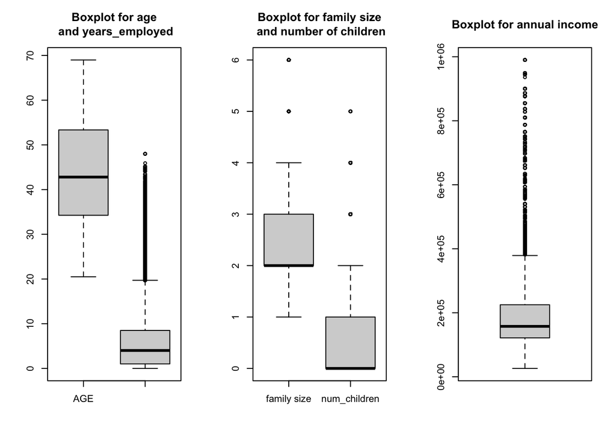

```r
#Convert your data set into a matrix
mat <- as.matrix(application_record[, c(5, 6, 16, 17, 18)])

#Change the variable names displayed on the x-axis in the boxplots
colnames(mat)[3] <- "family size"
colnames(mat)[1] <- "num_children"

#Set the layout of the plot area into one row and three columns
par(mfrow = c(1,3))

#Plot boxplots for each pair or single variable
boxplot(mat[,c(4,5)], main = "Boxplot for age\n and years_employed", horiz = TRUE)
boxplot(mat[,c(3,1)], main = "Boxplot for family size\n and number of children", horiz = TRUE)
boxplot(mat[,2], main = "Boxplot for annual income", horiz = TRUE)
```

##### Log transformation on “YEARS_EMPLOYED” after substituting 0 with .1 and on “AMT_INCOME_TOTAL” given the ‘application_record’ data set

```r
# Replace 0 with 0.1 in YEARS_EMPLOYED
application_record$YEARS_EMPLOYED[application_record$YEARS_EMPLOYED == 0] <- 0.1

# Do log transformation on YEARS_EMPLOYED and AMT_INCOME_TOTAL
application_record$log_YEARS_EMPLOYED <- log(application_record$YEARS_EMPLOYED)
application_record$log_AMT_INCOME_TOTAL <- log(application_record$AMT_INCOME_TOTAL)
```

##### Display a boxplot matrix of ‘EARS_EMPLOYED’ and annual income after log transformation

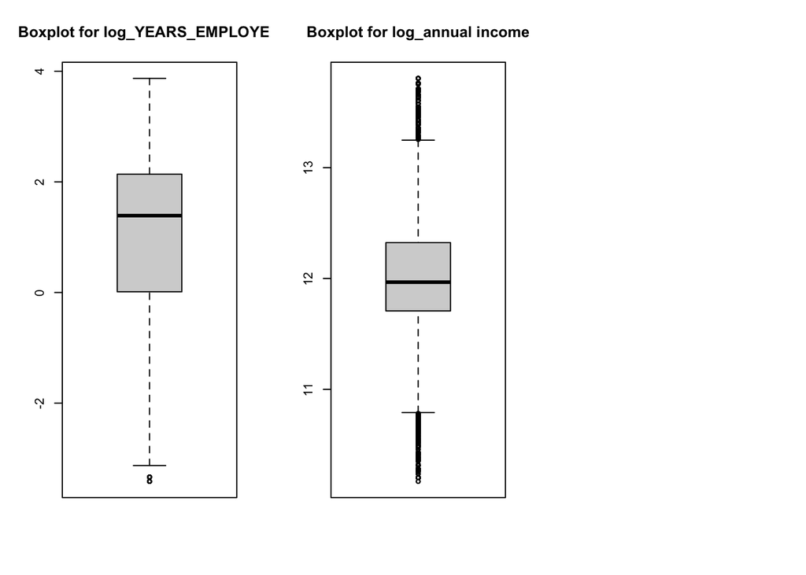

```r
#Convert your data set into a matrix
mat <- as.matrix(application_record[, c(5, 6, 16, 17, 18, 19, 20)])

#Set the layout of the plot area into one row and three columns
par(mfrow = c(1,3))

#Plot boxplots for each single variables
boxplot(mat[,6], main = "Boxplot for log_YEARS_EMPLOYED")
boxplot(mat[,7], main = "Boxplot for log_annual income")
```

##### Check for consistency in data

```r
# Checking for consistency in CNT_CHILDREN and CNT_FAM_MEMBERS columns of application_record dataset
table(application_record$CNT_CHILDREN, application_record$CNT_FAM_MEMBERS)
```

```
##
##          1      2      3      4      5      6
##   0  84326 219450      0      0      0      0
##   1     58  14205  74200      0      0      0
##   2     36      0   2871  36908      0      0
##   3      5      0      0    380   5043      0
##   4      0      0      0      0     36    450
##   5      0      0      0      0      0      9
```

The table illustrates the distribution of the number of children (CNT_CHILDREN) and family members (CNT_FAM_MEMBERS) in the application_record dataset. It shows the number of applications for each combination of children and family members, where the rows represent children and the columns represent family members.

##### Check for accuracy in data

```r
# IDs in application_record not in credit_record
app_not_credit <- sum(!application_record$ID %in% credit_record$ID)

# IDs in credit_record not in application_record
credit_not_app <- sum(!credit_record$ID %in% application_record$ID)

# IDs present in both datasets
common_ids <- intersect(application_record$ID, credit_record$ID)

# Count number of unique IDs
num_common_ids <- length(unique(common_ids))

cat("Number of IDs in application_record not in credit_record:", app_not_credit, "\n")
```

```
## Number of IDs in application_record not in credit_record: 401562
```

```r
cat("Number of IDs in credit_record not in application_record:", credit_not_app, "\n")
```

```
## Number of IDs in credit_record not in application_record: 271631
```

```r
cat("Number of unique IDs in both datasets:", num_common_ids, "\n")
```

```
## Number of unique IDs in both datasets: 36415
```

There are 401,562 IDs in the application_record dataset that are not present in the credit_record dataset. This suggests that not all individuals in the application_record dataset have a credit record, or that some individuals may have a credit record with another institution.

There are 271,631 IDs in the credit_record dataset that are not present in the application_record dataset. This could be due to several reasons, such as individuals having a credit record with the institution but not having applied for credit, or the credit record dataset containing records from multiple sources.

There are 36,415 unique IDs that are present in both datasets. These are the individuals who have both applied for credit and have a credit record with the institution. This information can be used for further analysis or modeling, such as exploring the relationship between creditworthiness and demographic or financial factors. However, it’s important to keep in mind that this is a relatively small subset of the overall data, and any conclusions drawn from this subset may not be representative of the entire population.

##### Merge the two datasets and save the cleaned dataset

```r
# Merge the two datasets on ID
credit_application <- merge(application_record, credit_record, by = "ID")

# Replace any empty strings, "N/A", or "NA" values with NA values in the credit_application data frame.
credit_application[] <- lapply(credit_application, function(x) ifelse(x %in% c("", "N/A", "NA"), NA, x))

# Save the cleaned dataset
write.csv(credit_application, "credit_application.csv", row.names = FALSE)
```

##### Create a cross-tabulation table (EDUCATION_TYPE and credit status)

```r
# Create a cross-tabulation table
cross_tab <- table(credit_application$NAME_EDUCATION_TYPE, credit_application$STATUS)
#cross_tab <- table(credit_application$CODE_GENDER, credit_application$STATUS)

# Print the cross-tabulation table
print(cross_tab)
```

```
##
##                                      0      1      2      3      4      5
##   Academic degree                  208      8      0      0      0      0
##   Higher education               77054   2252    225     80     55    577
##   Incomplete higher              11241    535     47     18     24     39
##   Lower secondary                 2708    112     14      5      8     40
##   Secondary / secondary special 199116   5809    515    183    127    871
##
##                                      C      X
##   Academic degree                  474    147
##   Higher education               90061  43028
##   Incomplete higher              13282   5143
##   Lower secondary                 4237   1531
##   Secondary / secondary special 221291  95879
```

The table displays the counts of education type and loan status category in the credit_application dataset. The loan status categories range from 0 to 5, C, and X, representing various loan statuses. Zero indicates that a payment is overdue by 1-29 days, while a rating of 5 indicates that a payment is more than 150 days overdue and is categorized as a bad debt. Additionally, a rating of C denotes that the payment was cleared during that month, whereas an X rating signifies the absence of any loan for the month.

The table is helpful in analyzing the relationship between education level and loan status to identify if certain levels of education have higher or lower rates of loan default or delinquency. Some potential insights include:

Overall, the cross-tabulation table can help identify potential risk factors associated with credit repayment and inform strategies to mitigate credit risk. However, further analysis may be needed to determine the statistical significance of the observed patterns and to identify potential confounding variables.

##### Create a bar plot of credit status by gender

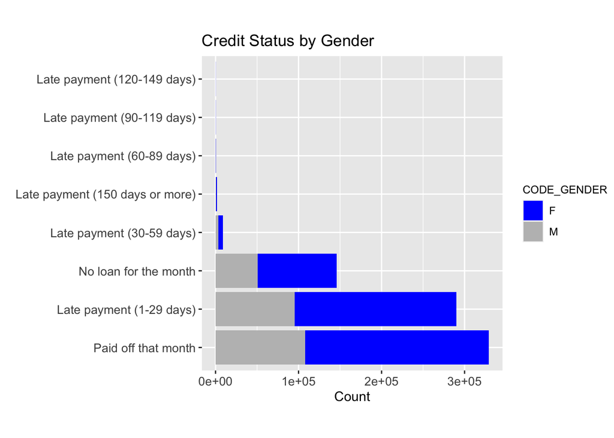

```r
# Group the data by gender and credit status and summarize the counts
df_CODE_GENDER <- credit_application %>% group_by(CODE_GENDER, STATUS) %>% summarize(count = n(), .groups = "drop")

# Define a vector of status codes and labels
status_codes <- c("0", "1", "2", "3", "4", "5", "C", "X")
status_labels <- c("Late payment (1-29 days)", "Late payment (30-59 days)", "Late payment (60-89 days)", "Late payment (90-119 days)",
                   "Late payment (120-149 days)", "Late payment (150 days or more)", "Paid off that month", "No loan for the month")

# Loop over the status codes and labels and mutate the STATUS column accordingly
for (i in seq_along(status_codes)) {
  df_CODE_GENDER <- mutate(df_CODE_GENDER, STATUS = ifelse(STATUS == status_codes[i], status_labels[i], STATUS))
}

# Generate a stacked bar chart
ggplot(df_CODE_GENDER, aes(x = reorder(STATUS, -count), y = count, fill = CODE_GENDER )) +
  geom_bar(stat = "identity") +
  scale_fill_manual(values=c("blue", "gray")) + # add this line to set the fill colors
#  scale_y_log10() +
  coord_flip() +
  theme(axis.text.x = element_text(size = 10), axis.text.y = element_text(size = 10)) +
  labs(title = "Credit Status by Gender", x = "", y = "Count", fill = "CODE_GENDER") +
  theme(
        plot.margin = unit(c(1,0,1,0), "cm")) +
        theme(axis.text.x = element_text(size = 10), axis.text.y = element_text(size = 10)) +

        theme(axis.text.x = element_text(size = 10), axis.text.y = element_text(size = 10)) +
        theme(legend.title = element_text(size = 9))
```

Based on the data provided, we can draw the following insights regarding credit status between male and female:

Overall, females seem to have a higher number of late payments than males. For example, there were 194,962 instances where females had payment delayed for 1-29 days, compared to 95,692 for males. Similarly, females had more instances of delayed payments for longer periods of time (60-89 days, 90-119 days, and 120-149 days).

Finally, the “No loan for the month” column indicates that there were no loans for some months. We cannot draw any insights from this column alone.

##### Create a matrix of scatterplots for “CNT_CHILDREN”, “AMT_INCOME_TOTAL”, “CNT_FAM_MEMBERS”, “AGE”, and “YEARS_EMPLOYED” variables in application_record

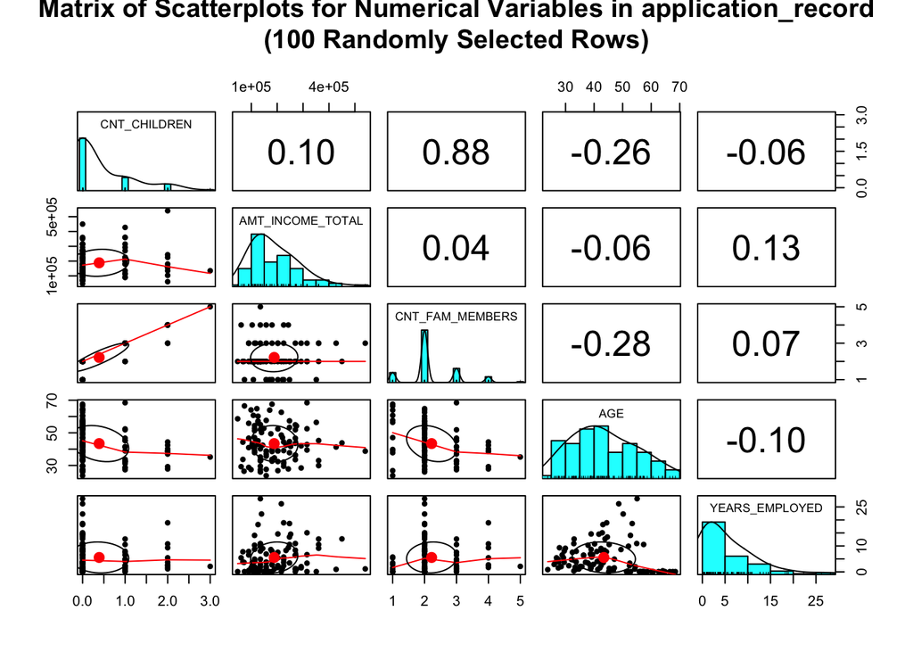

```r
# Create a random sample of 50 points from the original dataset
set.seed(123)
sampled_data <- credit_application %>% sample_n(100)

# Create scatterplot matrix for the subsetted data
#ggpairs(sampled_data[, c(5, 6, 16, 17, 18)], axisLabels = "show", progress = FALSE) +
#  ggtitle("Matrix of Scatterplots for Numerical Variables in application_record\n(100 Randomly Selected Rows)")

# Create scatterplot matrix
pairs.panels(sampled_data[, c(5, 6, 16, 17, 18)],
main = "Matrix of Scatterplots for Numerical Variables in application_record\n(100 Randomly Selected Rows)")
```

##### Perform Chi-square test to reveal relationship between credit status and categorical variables in dataset

```r
# Get the names of all categorical variables
cat_vars <- names(credit_application)[sapply(credit_application, is.character)]

# Loop through each variable and convert it to factor
for (var in cat_vars) {
  credit_application[[var]] <- as.factor(credit_application[[var]])
}

# Get the names of all categorical variables except credit status
cat_vars <- names(credit_application)[sapply(credit_application, is.factor)]
cat_vars <- cat_vars[cat_vars != "STATUS"]

# Loop through each variable and perform chi-square test with credit status
for (var in cat_vars) {
  print(paste("Chi-square test for", var))
  print(chisq.test(credit_application$STATUS, credit_application[[var]]))
}
```

```
## [1] "Chi-square test for CODE_GENDER"
##
##  Pearson's Chi-squared test
##
## data:  credit_application$STATUS and credit_application[[var]]
## X-squared = 364.11, df = 7, p-value < 2.2e-16
##
## [1] "Chi-square test for FLAG_OWN_CAR"
##
##  Pearson's Chi-squared test
##
## data:  credit_application$STATUS and credit_application[[var]]
## X-squared = 123.63, df = 7, p-value < 2.2e-16
##
## [1] "Chi-square test for FLAG_OWN_REALTY"
##
##  Pearson's Chi-squared test
##
## data:  credit_application$STATUS and credit_application[[var]]
## X-squared = 156.62, df = 7, p-value < 2.2e-16
##
## [1] "Chi-square test for NAME_INCOME_TYPE"
##
##  Pearson's Chi-squared test
##
## data:  credit_application$STATUS and credit_application[[var]]
## X-squared = 521.47, df = 28, p-value < 2.2e-16
##
## [1] "Chi-square test for NAME_EDUCATION_TYPE"
##
##  Pearson's Chi-squared test
##
## data:  credit_application$STATUS and credit_application[[var]]
## X-squared = 1068.2, df = 28, p-value < 2.2e-16
##
## [1] "Chi-square test for NAME_FAMILY_STATUS"
##
##  Pearson's Chi-squared test
##
## data:  credit_application$STATUS and credit_application[[var]]
## X-squared = 630.08, df = 28, p-value < 2.2e-16
##
## [1] "Chi-square test for NAME_HOUSING_TYPE"
##
##  Pearson's Chi-squared test
##
## data:  credit_application$STATUS and credit_application[[var]]
## X-squared = 454.37, df = 35, p-value < 2.2e-16
##
## [1] "Chi-square test for OCCUPATION_TYPE"
##
##  Pearson's Chi-squared test
##
## data:  credit_application$STATUS and credit_application[[var]]
## X-squared = 2609.8, df = 119, p-value < 2.2e-16
```

The results of the chi-square tests suggest that there is a significant relationship between the “STATUS” variable and all other categorical variables in the credit_application dataset, except for “STATUS” itself.

For example, the chi-square test for “CODE_GENDER” suggests that there is a significant relationship between gender and credit status. Similarly, the chi-square tests for “FLAG_OWN_CAR” and “FLAG_OWN_REALTY” suggest that ownership of a car or real estate is related to credit status.

Overall, the results of the chi-square tests suggest that the categorical variables in the credit_application dataset are associated with credit status, and may be useful in predicting credit risk.

#### CONCLUSION

Based on the data preprocessing and EDA steps performed in this study, we have obtained a more refined and structured dataset, though it is an iterative process that may continue during further analysis as we gain a better understanding of the data. The next step would be to use the data to conduct further analysis and identify the key factors that are most predictive of credit card default or delinquency.

To identify these factors, we can leverage various statistical and machine learning techniques, including logistic regression, decision trees, random forests, LDA, and SVM. These methods will help us comprehend the interrelationships between various variables and their impact on credit card default or delinquency.

Once we have identified these factors, we can use them to enhance risk assessment and management. For instance, we can create a credit scoring model that factors in these variables to forecast the likelihood of credit card default or delinquency. This model can be used to evaluate the creditworthiness of individuals and determine the credit limits and interest rates they are offered, thereby improving the overall credit risk management process.

#### REFERENCES

Aggarwal, C. C. (2017). *Outlier analysis* (Second edition.). Springer. https://doi.org/10.1007/978-3-319-47578-3

Chen, C., Härdle, W., & Unwin, A. (2007). *Handbook of data visualization.* Springer.

*Contributed packages.* CRAN. (n.d.). Retrieved March 2, 2023, from https://cran.r-project.org/web/packages/

*GGPLOT2 / R / data.R.* GitHub. (2022, March 15). Retrieved February 28, 2023, from https://github.com/tidyverse/ggplot2/blob/HEAD/R/data.R

Kabacoff, R. (2015). *R in action: data analysis and graphics with R* (Second edition.). Manning Publications.

Run R code online. (n.d.). Retrieved March 2, 2023, from https://rdrr.io/snippets/